# Monte Carlo

Lecture 11

March 3, 2024

# Review

## Random Variable Generation

- Quantile transform method turns uniforms into known distributions.
- Rejection sampling can be used when quantiles are difficult to compute (but requires proposal covering target distribution).
- Pseudorandom number generation and importance of seeds.

# Monte Carlo Simulation

## Stochastic Simulation

**Goal**: Estimate $\mathbb{E}_p\left[h(x)\right]$, $x \sim f(x)$

**Monte Carlo principle**:

- Sample $x^1, x^2, \ldots, x^N \sim f(x)$
- Estimate $\mathbb{E}_p\left[h(x)\right] \approx \sum_{n=1}^N h(x^n)$ / N

**In other words**: replace calculus with data summaries!

## Monte Carlo Process Schematic

[figure not shown]

## Goals of Monte Carlo

Monte Carlo is a broad method, which can be used to:

1. Obtain probability distributions of outputs;
2. Estimate deterministic quantities (*Monte Carlo estimation*).

## MC Example: Finding $\pi$

How can we use MC to estimate $\pi$?

**Hint**: Think of $\pi$ as an expected value…

## MC Example: Finding $\pi$

Finding $\pi$ by sampling random values from the unit square and computing the fraction in the unit circle. This is an example of **Monte Carlo integration**.

$$\frac{\text{Area of Circle}}{\text{Area of Square}} = \frac{\pi}{4}$$

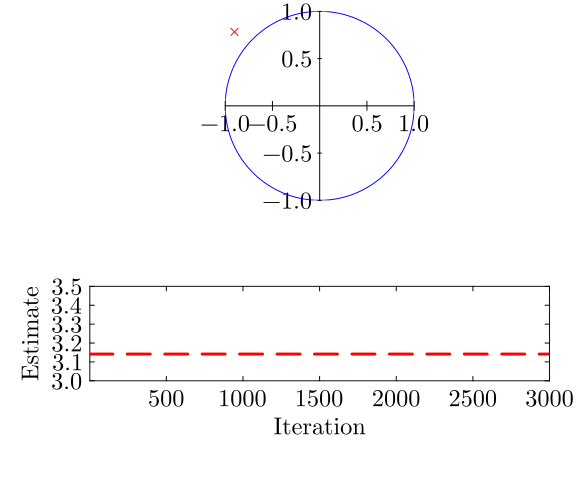

```julia
Logging.disable_logging(Logging.Info)

function circleShape(r)
    θ = LinRange(0, 2 * π, 500)
    r * sin.(θ), r * cos.(θ)
end

nsamp = 3000
unif = Uniform(-1, 1)
x = rand(unif, (nsamp, 2))
l = mapslices(v -> sum(v.^2), x, dims=2)
in_circ = l .< 1
pi_est = [4 * mean(in_circ[1:i]) for i in 1:nsamp]

plt1 = plot(
    1,
    xlim = (-1, 1),
    ylim = (-1, 1),
    legend = false,
    markersize = 4,
    framestyle = :origin,
    tickfontsize=16,
    grid=:false
    )
plt2 = plot(
    1,
    xlim = (1, nsamp),
    ylim = (3, 3.5),
    legend = :false,
    linewidth=3,
    color=:black,
    tickfontsize=16,
    guidefontsize=16,
    xlabel="Iteration",
    ylabel="Estimate",
    right_margin=5mm
)
hline!(plt2, [π], color=:red, linestyle=:dash)
plt = plot(plt1, plt2, layout=Plots.grid(2, 1, heights=[2/3, 1/3]), size=(600, 500))

plot!(plt, circleShape(1), linecolor=:blue, lw=1, aspectratio=1, subplot=1)


mc_anim = @animate for i = 1:nsamp
    if l[i] < 1
        scatter!(plt[1], Tuple(x[i, :]), color=:blue, markershape=:x, subplot=1)
    else
        scatter!(plt[1], Tuple(x[i, :]), color=:red, markershape=:x, subplot=1)
    end
    push!(plt, 2, i, pi_est[i])
end every 100

gif(mc_anim, "figures/mc_pi.gif", fps=3)
```

## MC Example: Dice

What is the probability of rolling 4 dice for a total of 19?

Can simulate dice rolls and find the frequency of 19s among the samples.

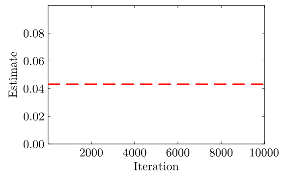

```julia
function dice_roll_repeated(n_trials, n_dice)
    dice_dist = DiscreteUniform(1, 6)
    roll_results = zeros(n_trials)
    for i=1:n_trials
        roll_results[i] = sum(rand(dice_dist, n_dice))
    end
    return roll_results
end

nsamp = 10000
# roll four dice 10000 times
rolls = dice_roll_repeated(nsamp, 4)

# calculate probability of 19
sum(rolls .== 19) / length(rolls)

# initialize storage for frequencies by sample length
avg_freq = zeros(length(rolls))
std_freq = zeros(length(rolls))

# compute average frequencies of 19
avg_freq[1] = (rolls[1] == 19)
count = 1
for i=2:length(rolls)
    avg_freq[i] = (avg_freq[i-1] * (i-1) + (rolls[i] == 19)) / i
    std_freq[i] = 1/sqrt(i-1) * std(rolls[1:i] .== 19)
end

plt = plot(
    1,
    xlim = (1, nsamp),
    ylim = (0, 0.1),
    legend = :false,
    tickfontsize=16,
    guidefontsize=16,
    xlabel="Iteration",
    ylabel="Estimate",
    right_margin=8mm,
    color=:black,
    linewidth=3,
    size=(600, 400)
)
hline!(plt, [0.0432], color="red",
    linestyle=:dash)

mc_anim = @animate for i = 1:nsamp
    push!(plt, 1, i, avg_freq[i])
end every 100

gif(mc_anim, "figures/mc_dice.gif", fps=10)
```

## Monte Carlo and Uncertainty Propagation

**Monte Carlo simulation**: propagate uncertainties from inputs through a model to outputs.

This is an example of **uncertainty propagation**: draw samples from some distribution, and run them through one or more models to find the (conditional) probability of outcomes of interest (for good or bad).

# Why Monte Carlo Works

## Monte Carlo: Formal Approach

**Formally**: Monte Carlo estimation as the computation of the expected value of a random quantity $Y = f(X)$, $\mu = \mathbb{E}[Y]$.

To do this, generate $n$ independent and identically distributed values $Y_1, \ldots, Y_n$. Then the sample estimate is

$$\tilde{\mu}_n = \frac{1}{n}\sum_{i=1}^n Y_i$$

## What Makes a Good Statistical Estimator?

Statistical estimators are **random**, which means we can’t ever guarantee that we get back the “true” value

- No bias ($\text{Bias} = \mathbb{E}_g[\tilde{\mu}] - \mu$)
- Well-characterized, ideally small, variance ($\text{Var}(\tilde{\mu})$)

## The Law of Large Numbers

If

1. $Y$ is a random variable and its expectation exists and
2. $Y_1, \ldots, Y_n$ are independently and identically distributed

Then by the **weak law of large numbers**:

$$\lim_{n \to \infty} \mathbb{P}\left(\left|\tilde{\mu}_n - \mu\right| \leq \varepsilon \right) = 1$$

## The Law of Large Numbers

In other words, *eventually* Monte Carlo estimates will get within an arbitrary error of the true expectation.

But how large is large enough?

## Monte Carlo Sample Mean

The sample mean $\tilde{\mu}_n = \frac{1}{n}\sum_{i=1}^n Y_i$ is itself a random variable.

With some assumptions (the mean of $Y$ exists and $Y$ has finite variance), the expected Monte Carlo sample mean $\mathbb{E}[\tilde{\mu}_n]$ is

$$\frac{1}{n}\sum_{i=1}^n \mathbb{E}[Y_i] = \frac{1}{n} n \mu = \mu$$

## Monte Carlo Error

We’d like to know more about the error of this estimate for a given sample size. The variance of this estimator is

$$\tilde{\sigma}_n^2 = \text{Var}\left(\tilde{\mu}_n\right) = \mathbb{E}\left((\tilde{\mu}_n - \mu)^2\right) = \frac{\sigma_Y^2}{n}$$

So as $n$ increases, the *standard error* decreases:

$$\tilde{\sigma}_n = \frac{\sigma_Y}{\sqrt{n}}$$

## Monte Carlo Error

In other words, if we want to decrease the Monte Carlo error by 10x, we need 100x additional samples. **This is not an ideal method for high levels of accuracy.**

> Monte Carlo is an extremely bad method. It should only be used when all alternative methods are worse.

— Sokal, *Monte Carlo Methods in Statistical Mechanics*, 1996

But…often most alternatives *are* worse!

## When Might We Want to Use Monte Carlo?

If you can compute your integrals analytically or through quadrature, you probably should.

But for *many* “real” problems, this is either

1. Not possible (or computationally intractable);
2. Requires a lot of stylization and simplification.

## Monte Carlo Confidence Intervals

**Basic Idea**: The *Central Limit Theorem* says that with enough samples, the errors are normally distributed:

$$\left\|\tilde{\mu}_n - \mu\right\| \to \mathcal{N}\left(0, \frac{\sigma_Y^2}{n}\right)$$

## Monte Carlo Confidence Intervals

The $\alpha$-confidence interval is:
$$\tilde{\mu}_n \pm \Phi^{-1}\left(1 - \frac{\alpha}{2}\right) \frac{\sigma_Y}{\sqrt{n}}$$

For example, the 95% confidence interval is
$$\tilde{\mu}_n \pm 1.96 \frac{\sigma_Y}{\sqrt{n}}.$$

## Sidebar: Estimating $\sigma_Y$

We don’t know the standard deviation $\sigma_Y$.

## Implications of Monte Carlo Error

Converging at a rate of $1/\sqrt{n}$ is not great. But:

- All models are wrong, and so there always exists some irreducible model error.
- We often need a lot of simulations. Do we have enough computational power?

# Monte Carlo Example

## Airshed Model

[figure not shown]

Figure 3: Illustration of the airshed, including notation.

**Goal**: Find the probability of exceeding the 1-hour SO<sub>2</sub> average exposure concentration standard, which is 0.14 ppm.

$$\mathbb{P}[\text{SO}_2(\theta) > 0.14] = \int \mathbb{I}(\text{SO}_2(\theta) > 0.14) p(\theta) d\theta$$

## Airshed Model

[figure not shown]

Figure 4: Illustration of the airshed, including notation.

$$\frac{dC}{dt} = \frac{u}{L} C_\text{in} + \frac{S-D}{WHL} - \left(\frac{u}{L} + k\right)C$$

## Forward Euler Discretization

$$\frac{dC}{dt} = \frac{u}{L} C_\text{in}(t) + \frac{S-D}{WHL} - \left(\frac{u}{L} + k\right)C$$

$$\Rightarrow \frac{C(t+1) - C(t)}{\Delta t} = \frac{u}{L} C_\text{in}(t) + \frac{R}{WHL} - \left(\frac{u}{L} + k\right)C(t)$$

$$\bbox[yellow, 10px, border:5px solid red]{C(t+1) = \left(1 - \Delta t\left(\frac{u}{L} + k\right)\right)C(t) + \Delta t \left(\frac{u}{L} C_\text{in}(t) + \frac{R}{WHL}\right)}$$

## Monte Carlo Samples

```julia
nsamp = 1000
u = rand(LogNormal(log(2), 1), nsamp)
Cin = rand(LogNormal(log(0.16), 0.12), nsamp)
R = rand(Normal(0.5, 0.5), nsamp)

p1 = histogram(u, ylabel="count", xlabel=L"$u$ (m/s)", label=false, tickfontsize=16, guidefontsize=18, size=(400, 450))
p2 = histogram(Cin, ylabel="count", xlabel=L"$C_{in}$ (ppm)", label=false, tickfontsize=16, guidefontsize=18, size=(400, 450))
p3 = histogram(R, ylabel="count", xlabel=L"$R$ (ppm/hr)", label=false, tickfontsize=16, guidefontsize=18, size=(400, 450))
display(p1)
display(p2)
display(p3)
```

[figure not shown]

(a) Monte Carlo samples for the airshed model.

[figure not shown]

(b)

[figure not shown]

(c)

Figure 5

## Simulation Results

```julia
# other parameters
C₀ = 0.07
T = 60
k = 0.3
W = 4
H = 5
L = 4
# conduct simulation
P = u / L .* Cin
l = u / L .+ k
C2 = zeros(T*100 + 1, nsamp)
S = 0:0.01:T
for (i, t) in pairs(S)
    if i == 1
        C2[i, :] .= C₀
    else
        C2[i, :] = (1 .- 0.01*l) .* C2[i-1, :] .+ 0.01 * P .+ 0.01 * R / (H * W * L)
    end
end
mean_SO2 = map(mean, eachcol(C2)) # calculate means
# plot histogram
p1 = histogram(mean_SO2, xlabel="1-Hour Average Exposure (ppm)", ylabel="Count", legend=false, tickfontsize=16, guidefontsize=18)
vline!(p1, [0.14], color=:red, linestyle=:dash, linewidth=3)
xticks!(p1, 0:0.04:0.3)
xaxis!(p1, xminorticks=2)
plot!(p1, size=(600, 450))
# plot cdf
p2 = plot(sort(mean_SO2), (1:nsamp) ./ nsamp, xlabel="1-Hour Average Exposure (ppm)", ylabel="Cumulative Probability", legend=false, tickfontsize=17, guidefontsize=18, linewidth=3)
vline!(p2, [0.14], linestyle=:dash, color=:red, linewidth=3, minorgrid=true)
xticks!(p2, 0:0.04:0.3)
xaxis!(p2, xminorticks=2)
yaxis!(p2, yminorticks=5)
plot!(p2, size=(600, 450))

display(p1)
display(p2)
```

[figure not shown]

(a) Monte Carlo samples for the airshed model.

[figure not shown]

(b)

Figure 6

## Monte Carlo Estimation

$$\hat{\mu}_n = \frac{1}{n}\sum_{i=1}^n \mathbb{I}[x_i > 0.14]$$

$$\hat{\sigma}_n = \sqrt{\frac{\text{Var}(\mathbb{I}[x_{1:n} > 0.14])}{n}}$$

```julia
# show Monte Carlo estimate stabilization
avg_mc_out = zeros(nsamp)
avg_mc_out[1] = mean_SO2[1] > 0.14
std_mc_out = zeros(nsamp)
std_mc_out[1] = 0
for i = 2:nsamp
    avg_mc_out[i] = (avg_mc_out[i-1] * (i-1) + (mean_SO2[i] > 0.14)) / i
    std_mc_out[i] = 1/sqrt(i) * std(mean_SO2[1:i] .> 0.14)
end
p = plot(avg_mc_out, xlabel="Monte Carlo Iteration", ylabel="Probability", left_margin=3mm, legend=:false, ribbon=1.96*std_mc_out, fillalpha=0.3, linewidth=2, tickfontsize=16, guidefontsize=18, fillcolor=:red, right_margin=5mm, minorgrid=true)
ylims!(p, (0, 0.3))
yaxis!(p, yminorticks=5)
plot!(p, size=(600, 450))
display(p)
```

[figure not shown]

Figure 7: Monte Carlo estimation for the airshed model.

## Monte Carlo Optimization

Can also use Monte Carlo to estimate expected values for optimization problems

For example: in previous problem, might try to optimize a control strategy with an objective of minimizing violations. But no closed form representation of the distribution, so use MC.

# Estimating Quantiles with Monte Carlo

## MC Estimate of the CDF

Would like to estimate the CDF $F$ with some approximation $\hat{F}_n$, then compute $\hat{z}^\alpha_n = \hat{F}_n^{-1}(\alpha)$ as an estimator of the $\alpha$-quantile $z^\alpha$.

Given samples $\hat{\mathbf{y}} = y_1, \ldots, y_n \sim F$, define
$$\hat{F}_(y) = \frac{1}{n} \sum_{i=1}^n \mathbb{I}(y_i \leq y).$$

## Is This An Unbiased Estimator?

$$\begin{align*}
\mathbb{E}[\hat{F}_(y)] &= \frac{1}{n} \sum_{i=1}^n \mathbb{I}(y_i \leq y) \\
&= \frac{1}{n} \sum_{i=1}^n \mathbb{P}(y_i \leq y) \\
&= F(y)
\end{align*}$$

## Monte Carlo Quantile Estimation Error

From the CLT and some (not super important) theory about order statistics:
$$\text{Var}(\hat{z}^\alpha_n) \to \frac{\sigma^2_y}{n}\frac{\alpha (1 - \alpha)}{f^2(z^\alpha)}$$

In other words, **the smaller the density at the “true” quantile $z^\alpha$, the greater the error**.

# More Advanced Monte Carlo Methods (Teasers)

## What If We Can’t Sample From The Distribution?

- May not be able to generate samples $X \sim f(x)$ efficiently
- Think of sampling from tails:

$$P(X > k) \approx \frac{1}{M} \sum_{i=1}^M \mathbb{I}(X_i > k)$$

## Importance Sampling

Extension of rejection sampling without requiring “rejection”:

1. Draw samples from *importance distribution* g(x);
2. Reweight samples:
   $$\begin{align*}
   \mathbb{E}_f[h(x)] &= \int_x \frac{f(x)}{g(x)} g(x)h(x) dx \\
   &\approx \frac{1}{M} \sum_{i=1}^M \frac{f(x)}{g(x)}h(x)
   \end{align*}$$

## Importance Sampling Needs

Technically works with any proposal $g$, but more efficient if $g$ “covers” $f$ (like with rejection sampling):

$$f(x)/g(x) < M < \infty$$

## Antithetic Variates

If target values of pairs of samples $h(X_i$) and $h(Y_i)$ are negatively correlated, can increase rate of convergence of
$$\frac{1}{2M} \sum_{i=1}^M [h(X_i) + h(Y_i)]$$
relative to $\frac{1}{2M} h(X_i)$ alone.

## Antithetic Variate Generation Can Be Difficult in Practice

- Ensuring anti-correlation can be difficult to verify in general;
- Gains in efficiency are dependent on effectiveness of antithetical variate generation and shape of $h(x)$

# Key Points

## Key Points

- Monte Carlo: stochastic simulation instead of integration to estimate expected values
- Monte Carlo is an unbiased estimator; confidence intervals given by CLT.
- Be mindful of Monte Carlo standard error for “naive” MC with iid samples.
- **Advanced**: Variance reduction techniques to improve convergence, see e.g. https://artowen.su.domains/mc/Ch-var-basic.pdf.

## Perhaps Most Importantly…

**Always report Monte Carlo error!**

# Upcoming Schedule

## Next Classes

**Wednesday**: The Bootstrap

# References

## References (Scroll for Full List)